# Midterm2-yslin3-STAT425

Rosa Lin

11/14/2020

```r
library(faraway)
```

```r
library(ggplot2)
library(MASS)
```

## Question 1

In an experiment to study the gain in weight of rats fed on four different diets, distinguished by the amount of protein (low and high) and by source of protein (beef and cereal), 10 rats were randomized to each of the 4 treatments and the weight gain in grams recorded. The data is in the file rats.txt. The variables are: ID = Observation Number; Source: Source of Protein (beef or cereal); Amount: Amount of protein (low, high); Wgain = Gain in weight in grams

1. Make appropriate plots of the data.

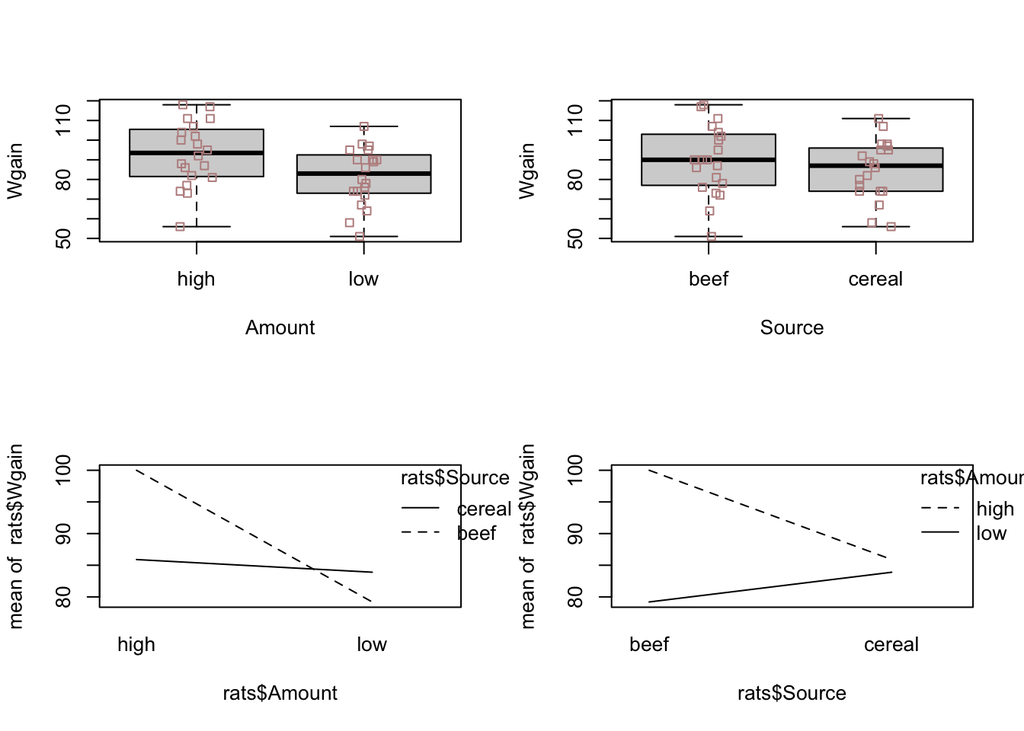

```r
par(mfrow = c(2,2))
boxplot(Wgain ~ Amount , data = rats, outline = FALSE)
stripchart(Wgain ~ Amount, data = rats, method = "jitter", col = "rosybrown", vertical = TRUE, add = TRUE)
boxplot(Wgain ~ Source, data = rats, outline = FALSE)
stripchart(Wgain ~ Source, data = rats, method = "jitter", col = "rosybrown", vertical = TRUE, add = TRUE)
interaction.plot(rats$Amount, rats$Source, rats$Wgain)
interaction.plot(rats$Source, rats$Amount, rats$Wgain)
```

2. Determine whether there is an interaction between amount of protein and source of protein.

```r
mod1 = lm(Wgain ~ Source * Amount, data = rats)
summary(mod1)
```

```
##
## Call:
## lm(formula = Wgain ~ Source * Amount, data = rats)
##
## Residuals:
##    Min     1Q Median     3Q    Max
## -29.90  -9.90   2.05  10.85  25.10
##
## Coefficients:
##                        Estimate Std. Error t value Pr(>|t|)
## (Intercept)             100.000      4.729  21.148  < 2e-16 ***
## Sourcecereal            -14.100      6.687  -2.109  0.04201 *
## Amountlow               -20.800      6.687  -3.110  0.00364 **
## Sourcecereal:Amountlow   18.800      9.457   1.988  0.05447 .
## ---
## Signif. codes:  0 '***' 0.001 '**' 0.01 '*' 0.05 '.' 0.1 ' ' 1
##
## Residual standard error: 14.95 on 36 degrees of freedom
## Multiple R-squared:   0.23,  Adjusted R-squared:  0.1658
## F-statistic: 3.584 on 3 and 36 DF,  p-value: 0.02297
```

```r
anova(mod1)
```

```
## Analysis of Variance Table
##
## Response: Wgain
##               Df Sum Sq Mean Sq F value  Pr(>F)
## Source         1  220.9  220.90  0.9879 0.32688
## Amount         1 1299.6 1299.60  5.8123 0.02114 *
## Source:Amount  1  883.6  883.60  3.9518 0.05447 .
## Residuals     36 8049.4  223.59
## ---
## Signif. codes:  0 '***' 0.001 '**' 0.01 '*' 0.05 '.' 0.1 ' ' 1
```

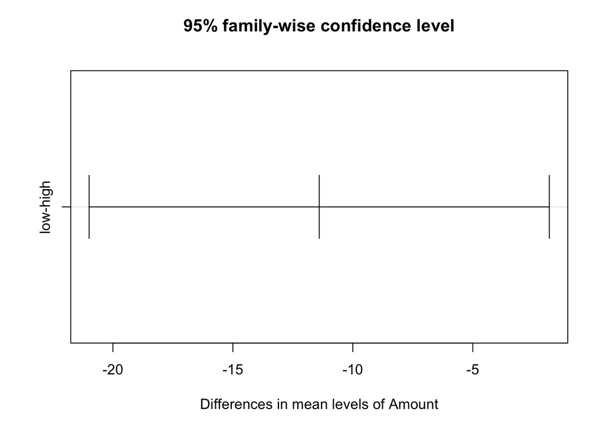

```r
int_mod = TukeyHSD(aov(Wgain ~ Amount * Source, data = rats), "Amount")
int_mod2 = TukeyHSD(aov(Wgain ~ Amount + Source, data = rats), "Source")
plot(int_mod)
```

3. Determine whether there are statistically significant differences between amounts and also source of protein.
4. Present regression diagnostics for your chosen model and comment whether the model assumptions have been met.

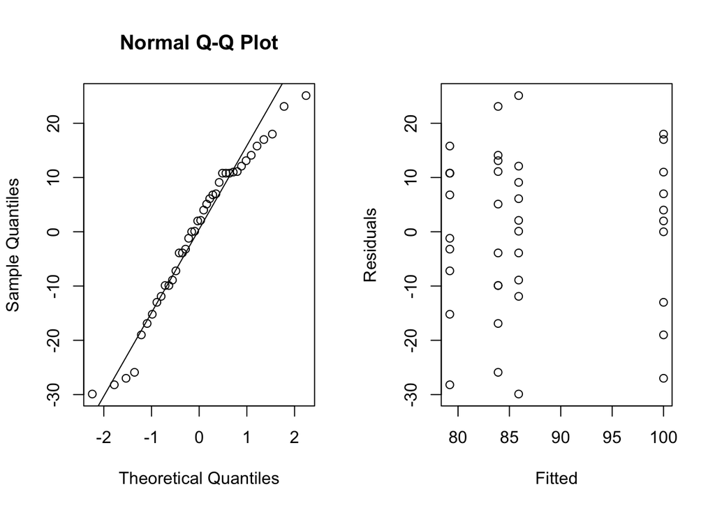

```r
par(mfrow = c(1,2))
qqnorm(mod1$residuals)
qqline(mod1$residuals)
plot(mod1$fitted.values, mod1$residuals, xlab = "Fitted", ylab = "Residuals")
```

The model assumption is not met.

## Question 2

Using the infmort data from the faraway library, find a simple model for the infant mortality in terms of the other variables. Be alert for transformations and unusual points. Interpret your model by explaining what the regression parameter estimates mean

```r
sim_mod = lm(mortality ~ ., data = infmort)
summary(sim_mod)
```

```
##
## Call:
## lm(formula = mortality ~ ., data = infmort)
##
## Residuals:
##     Min      1Q  Median      3Q     Max
## -156.00  -32.20   -4.44   13.65  488.82
##
## Coefficients:
##                     Estimate Std. Error t value Pr(>|t|)
## (Intercept)        2.152e+02  2.974e+01   7.234 1.19e-10 ***
## regionEurope      -1.015e+02  3.073e+01  -3.303 0.001351 **
## regionAsia        -4.589e+01  2.014e+01  -2.278 0.024977 *
## regionAmericas    -8.365e+01  2.180e+01  -3.837 0.000224 ***
## income            -5.290e-03  7.404e-03  -0.714 0.476685
## oilno oil exports -7.834e+01  2.891e+01  -2.710 0.007992 **
## ---
## Signif. codes:  0 '***' 0.001 '**' 0.01 '*' 0.05 '.' 0.1 ' ' 1
##
## Residual standard error: 77.36 on 95 degrees of freedom
##   (4 observations deleted due to missingness)
## Multiple R-squared:  0.3105, Adjusted R-squared:  0.2742
## F-statistic: 8.556 on 5 and 95 DF,  p-value: 1.015e-06
```

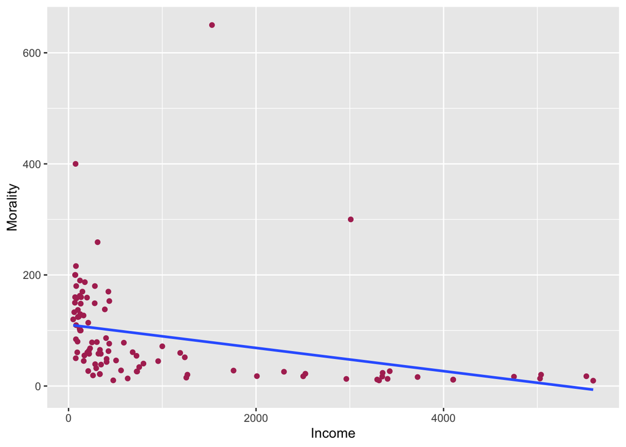

```r
ggplot(data = infmort, aes(x = income, y = mortality)) +
  geom_point(color = 'maroon') +
  geom_smooth(method = 'lm', formula = y ~ x, se = FALSE) +
  labs(x = 'Income', y = 'Morality')
```

Plot does not fit well.

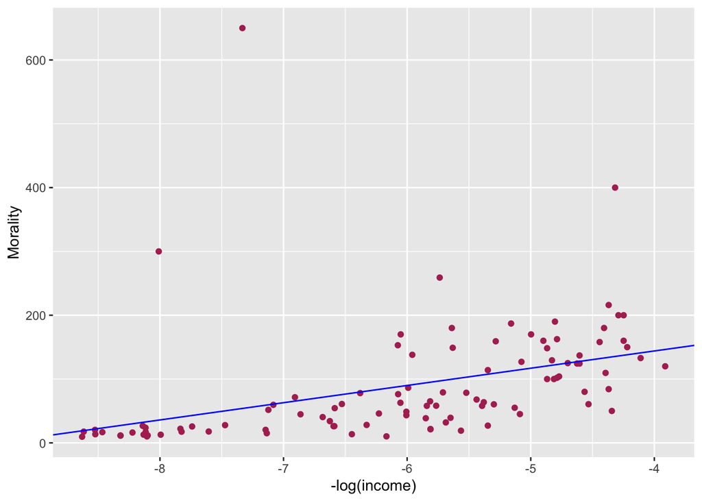

```r
log_mod = lm(mortality ~ I(-log(income)), data = infmort)
ggplot(data = infmort, aes(x = -log(income), y = mortality)) +
  geom_point(color = 'maroon') +
  geom_abline(intercept = coef(log_mod)[1], slope = coef(log_mod)[2], color = 'blue') +
  labs(x = '-log(income)', y = 'Morality')
```

Plot seems to fit better after using -log(income) instead of all variables as predictors.

```r
sim_mod2 = lm(mortality ~ region + oil + I(-log(income)), data = infmort)
summary(sim_mod2)
```

```
##
## Call:
## lm(formula = mortality ~ region + oil + I(-log(income)), data = infmort)
##
## Residuals:
##     Min      1Q  Median      3Q     Max
## -157.89  -34.33   -3.33   14.68  497.00
##
## Coefficients:
##                   Estimate Std. Error t value Pr(>|t|)
## (Intercept)        276.479     57.696   4.792 6.09e-06 ***
## regionEurope       -84.334     33.411  -2.524  0.01326 *
## regionAsia         -41.095     20.508  -2.004  0.04793 *
## regionAmericas     -72.369     24.011  -3.014  0.00331 **
## oilno oil exports  -84.558     29.290  -2.887  0.00482 **
## I(-log(income))     11.234      8.666   1.296  0.19799
## ---
## Signif. codes:  0 '***' 0.001 '**' 0.01 '*' 0.05 '.' 0.1 ' ' 1
##
## Residual standard error: 76.89 on 95 degrees of freedom
##   (4 observations deleted due to missingness)
## Multiple R-squared:  0.3188, Adjusted R-squared:  0.283
## F-statistic: 8.894 on 5 and 95 DF,  p-value: 5.906e-07
```

```r
sim_mod3 = boxcox(sim_mod)
```

[figure not shown]

Transform Y using log:

```r
trans_mod = lm(log(mortality) ~ ., data = infmort)
summary(trans_mod)
```

```
##
## Call:
## lm(formula = log(mortality) ~ ., data = infmort)
##
## Residuals:
##      Min       1Q   Median       3Q      Max
## -1.63943 -0.32722  0.03984  0.30077  2.28450
##
## Coefficients:
##                     Estimate Std. Error t value Pr(>|t|)
## (Intercept)        5.383e+00  2.373e-01  22.686  < 2e-16 ***
## regionEurope      -1.341e+00  2.451e-01  -5.469 3.65e-07 ***
## regionAsia        -8.294e-01  1.607e-01  -5.161 1.34e-06 ***
## regionAmericas    -8.377e-01  1.739e-01  -4.818 5.49e-06 ***
## income            -2.358e-04  5.906e-05  -3.993 0.000129 ***
## oilno oil exports -4.790e-01  2.306e-01  -2.077 0.040511 *
## ---
## Signif. codes:  0 '***' 0.001 '**' 0.01 '*' 0.05 '.' 0.1 ' ' 1
##
## Residual standard error: 0.6171 on 95 degrees of freedom
##   (4 observations deleted due to missingness)
## Multiple R-squared:  0.6142, Adjusted R-squared:  0.5939
## F-statistic: 30.25 on 5 and 95 DF,  p-value: < 2.2e-16
```

All variables are significant. The next step is to combine the Y transformation and -log(income).

```r
fin_mod = lm(log(mortality) ~ region + oil + I(-log(income)), data = infmort)
summary(fin_mod)
```

```
##
## Call:
## lm(formula = log(mortality) ~ region + oil + I(-log(income)),
##     data = infmort)
##
## Residuals:
##     Min      1Q  Median      3Q     Max
## -1.4208 -0.3062 -0.0331  0.3091  2.4897
##
## Coefficients:
##                   Estimate Std. Error t value Pr(>|t|)
## (Intercept)        7.19231    0.44331  16.224  < 2e-16 ***
## regionEurope      -1.03383    0.25672  -4.027 0.000114 ***
## regionAsia        -0.71292    0.15757  -4.524 1.75e-05 ***
## regionAmericas    -0.54984    0.18449  -2.980 0.003657 **
## oilno oil exports -0.64021    0.22505  -2.845 0.005444 **
## I(-log(income))    0.33985    0.06658   5.104 1.70e-06 ***
## ---
## Signif. codes:  0 '***' 0.001 '**' 0.01 '*' 0.05 '.' 0.1 ' ' 1
##
## Residual standard error: 0.5908 on 95 degrees of freedom
##   (4 observations deleted due to missingness)
## Multiple R-squared:  0.6464, Adjusted R-squared:  0.6278
## F-statistic: 34.73 on 5 and 95 DF,  p-value: < 2.2e-16
```

## Question 3

Some near infrared spectra (NIR) on 60 samples of gasoline and corresponding octane numbers can be found by data(gasoline,package=”pls”). The NIR spectra were measured using diffuse reflectance as log(1/R) from 900 nm to 1700 nm in 2 nm intervals, giving 401 wavelengths. Compute the mean value for each wavelength and predict the corresponding response octane number using the following methods:

1. Principal Components Regression
2. Lasso Regression